# Storm’s Health and Economic Impacts

# Synopsis

We will analyse NOAA storm data that is collected from 1950 to 2011. Through the analysis, we will examine which event causes the most economic damages and which event has the most health impact by year. In order to see the yearly impacts of events, We will calculate yearly mean damages and yearly mean count of fatalities and injuries caused by each event.

# Loading and Processing Raw Data

This data is coming from U.S. National Oceanic and Atmospheric Adminstraion’s (NOAA) storm database. This database tracks characteristics of major storms and weather events in the United States, including when and where they occur, as well as estimates of any fatalities, injuries, and property damage. The data file (repdata-data-StormData.csv) includes the storm data from 1950 to November 2011. The documentation about the data can be found at:

- National Weather Service [Storm Data Documentation](https://d396qusza40orc.cloudfront.net/repdata%2Fpeer2_doc%2Fpd01016005curr.pdf)
- National Climatic Data Center Storm Events [FAQ](https://d396qusza40orc.cloudfront.net/repdata%2Fpeer2_doc%2FNCDC%20Storm%20Events-FAQ%20Page.pdf)

```r
storm.data <- read.csv("repdata-data-StormData.csv", stringsAsFactors = FALSE)
str(storm.data)
```

```
## 'data.frame':    902297 obs. of  37 variables:
##  $ STATE__   : num  1 1 1 1 1 1 1 1 1 1 ...
##  $ BGN_DATE  : chr  "4/18/1950 0:00:00" "4/18/1950 0:00:00" "2/20/1951 0:00:00" "6/8/1951 0:00:00" ...
##  $ BGN_TIME  : chr  "0130" "0145" "1600" "0900" ...
##  $ TIME_ZONE : chr  "CST" "CST" "CST" "CST" ...
##  $ COUNTY    : num  97 3 57 89 43 77 9 123 125 57 ...
##  $ COUNTYNAME: chr  "MOBILE" "BALDWIN" "FAYETTE" "MADISON" ...
##  $ STATE     : chr  "AL" "AL" "AL" "AL" ...
##  $ EVTYPE    : chr  "TORNADO" "TORNADO" "TORNADO" "TORNADO" ...
##  $ BGN_RANGE : num  0 0 0 0 0 0 0 0 0 0 ...
##  $ BGN_AZI   : chr  "" "" "" "" ...
##  $ BGN_LOCATI: chr  "" "" "" "" ...
##  $ END_DATE  : chr  "" "" "" "" ...
##  $ END_TIME  : chr  "" "" "" "" ...
##  $ COUNTY_END: num  0 0 0 0 0 0 0 0 0 0 ...
```

[output cut: 23 more lines]

We are going to look at health and economic impacts of each events arcoss US. So we will need only a few columns from the data - FATALITIES, INJURIES, PROPDMG, PROPDMGEXP, CROPDMG, CROPDMGEXP. We will also select Date information - we chose BGN_DATE - along with event type - EVTYPE.

Also column types are modified. We created a date column, the info of which is coming from BGN_DATE column. From this date colume, year column is created. Also EVTTYPE column becomes factor.

```r
columns <- c(2,8,23:28)
storm <- storm.data[,columns]
str(storm)
```

```
## 'data.frame':    902297 obs. of  8 variables:
##  $ BGN_DATE  : chr  "4/18/1950 0:00:00" "4/18/1950 0:00:00" "2/20/1951 0:00:00" "6/8/1951 0:00:00" ...
##  $ EVTYPE    : chr  "TORNADO" "TORNADO" "TORNADO" "TORNADO" ...
##  $ FATALITIES: num  0 0 0 0 0 0 0 0 1 0 ...
##  $ INJURIES  : num  15 0 2 2 2 6 1 0 14 0 ...
##  $ PROPDMG   : num  25 2.5 25 2.5 2.5 2.5 2.5 2.5 25 25 ...
##  $ PROPDMGEXP: chr  "K" "K" "K" "K" ...
##  $ CROPDMG   : num  0 0 0 0 0 0 0 0 0 0 ...
##  $ CROPDMGEXP: chr  "" "" "" "" ...
```

```r
storm$date <- as.Date(storm$BGN_DATE, "%m/%d/%Y %H:%M:%S")
storm$year <- strftime(storm$date, "%Y")
storm$EVTYPE <- as.factor(storm$EVTYPE)
```

Make Property Damage (PROPDMG) and Crop Damage (CROPDMG) columns as full number, using PROPDMGEXP and CROPDMGEXP (“K” for thousand, “M” for million, “B” for billion, all others are ignored). Then select only necessary columns.

```r
storm <- transform(storm, PROPDMG = ifelse(PROPDMGEXP == "K", PROPDMG * 1E3,
                                           ifelse(PROPDMGEXP == "M", PROPDMG * 1E6,
                                                  ifelse(PROPDMGEXP == "B",
                                                         PROPDMG * 1E9, PROPDMG))))
storm <- transform(storm, CROPDMG = ifelse(CROPDMGEXP == "K", CROPDMG * 1E3,
                                           ifelse(CROPDMGEXP == "M", CROPDMG * 1E6,
                                                  ifelse(CROPDMGEXP == "B",
                                                         CROPDMG * 1E9, CROPDMG))))
storm <- subset(storm, select = c("date", "year", "EVTYPE", "FATALITIES", "INJURIES", "PROPDMG", "CROPDMG"))
storm$total.dmg <- storm$PROPDMG + storm$CROPDMG
str(storm)
```

```
## 'data.frame':    902297 obs. of  8 variables:
##  $ date      : Date, format: "1950-04-18" "1950-04-18" ...
##  $ year      : chr  "1950" "1950" "1951" "1951" ...
##  $ EVTYPE    : Factor w/ 985 levels "   HIGH SURF ADVISORY",..: 834 834 834 834 834 834 834 834 834 834 ...
##  $ FATALITIES: num  0 0 0 0 0 0 0 0 1 0 ...
##  $ INJURIES  : num  15 0 2 2 2 6 1 0 14 0 ...
##  $ PROPDMG   : num  25000 2500 25000 2500 2500 2500 2500 2500 25000 25000 ...
##  $ CROPDMG   : num  0 0 0 0 0 0 0 0 0 0 ...
##  $ total.dmg : num  25000 2500 25000 2500 2500 2500 2500 2500 25000 25000 ...
```

Load dplyr library

```r
library(dplyr)
```

Group storm data by year and event type and compute the total dmage by the group

```r
storm.by.year.evt <- group_by(storm, year, EVTYPE)
storm.by.year.evt
```

```
## Source: local data frame [902,297 x 8]
## Groups: year, EVTYPE [2326]
##
##          date  year  EVTYPE FATALITIES INJURIES PROPDMG CROPDMG total.dmg
##        (date) (chr)  (fctr)      (dbl)    (dbl)   (dbl)   (dbl)     (dbl)
## 1  1950-04-18  1950 TORNADO          0       15   25000       0     25000
## 2  1950-04-18  1950 TORNADO          0        0    2500       0      2500
## 3  1951-02-20  1951 TORNADO          0        2   25000       0     25000
## 4  1951-06-08  1951 TORNADO          0        2    2500       0      2500
## 5  1951-11-15  1951 TORNADO          0        2    2500       0      2500
## 6  1951-11-15  1951 TORNADO          0        6    2500       0      2500
## 7  1951-11-16  1951 TORNADO          0        1    2500       0      2500
## 8  1952-01-22  1952 TORNADO          0        0    2500       0      2500
## 9  1952-02-13  1952 TORNADO          1       14   25000       0     25000
## 10 1952-02-13  1952 TORNADO          0        0   25000       0     25000
## ..        ...   ...     ...        ...      ...     ...     ...       ...
```

# 10 Most Economically Damaging Events

We compute total damage for each event at each year.

```r
sum.dmg<- summarise(storm.by.year.evt, sum.dmg = sum(total.dmg))
head(sum.dmg)
```

```
## Source: local data frame [6 x 3]
## Groups: year [6]
##
##    year  EVTYPE   sum.dmg
##   (chr)  (fctr)     (dbl)
## 1  1950 TORNADO  34481650
## 2  1951 TORNADO  65505990
## 3  1952 TORNADO  94102240
## 4  1953 TORNADO 596104700
## 5  1954 TORNADO  85805320
## 6  1955    HAIL         0
```

```r
dim(sum.dmg)
```

```
## [1] 2326    3
```

```r
length(unique(sum.dmg$EVTYPE))
```

```
## [1] 985
```

Dimension of sum.dmg shows that there are 2326 event and year combinations over 985 different event types. We will look at top 10 economically most sever events in terms of average damage an event cause through all the years.

We compute mean damage across year by event type. For this, first we group sum.dmg by event type. Then we compute mean damage for each event using summarise. Next we order the output, mean.dmg.by.evt, descendingly by mean value.

```r
sum.dmg.by.evt <- group_by(sum.dmg, EVTYPE)
mean.dmg.by.evt <- summarise(sum.dmg.by.evt, dmg = mean(sum.dmg))
mean.dmg.by.evt <- mean.dmg.by.evt[order(mean.dmg.by.evt$dmg, decreasing = TRUE),]
mean.dmg.by.evt
```

```
## Source: local data frame [985 x 2]
##
##                        EVTYPE         dmg
##                        (fctr)       (dbl)
## 1           HURRICANE/TYPHOON 17978428200
## 2                       FLOOD  7911562014
## 3                 STORM SURGE  3610295083
## 4              HURRICANE OPAL  3161846030
## 5   HEAVY RAIN/SEVERE WEATHER  2500000000
## 6                 RIVER FLOOD  2029680900
## 7  TORNADOES, TSTM WIND, HAIL  1602500000
## 8                   HURRICANE  1043587786
## 9                     TORNADO   924848614
## 10                FLASH FLOOD   924322588
## ..                        ...         ...
```

Load ggplot2 library for plotting. Take only top 10 most severe damage in its cost. Plot them in bar graph

```r
library(ggplot2)
```

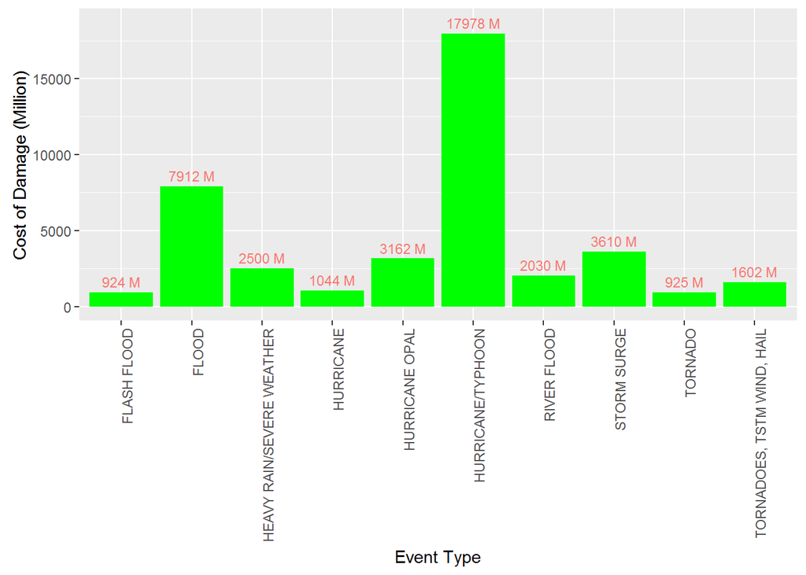

```r
mean.dmg.top <- mean.dmg.by.evt[1:10,]
mean.dmg.top$dmg <- mean.dmg.top$dmg / 1e6
g <- ggplot(mean.dmg.top, aes(x=EVTYPE, y=dmg))
g + geom_bar(stat="identity", fill="green") +
    theme(axis.text.x = element_text(angle = 90, hjust=1)) +
    geom_text(aes(label=paste(sprintf( "%1.0f", dmg), "M" ), y=dmg + 700, colour = "pink" ),
              size = 3, show.legend = FALSE) +
    xlab("Event Type") +ylab("Cost of Damage (Million)")
```

# Injuries and Fatalities caused by Storm

We calculate the total injury and fatality count of each event for every year.

```r
sum.inj.fat <- summarise(storm.by.year.evt, total.injuries=sum(INJURIES), total.fatalities = sum(FATALITIES))
sum.inj.fat
```

```
## Source: local data frame [2,326 x 4]
## Groups: year [?]
##
##     year    EVTYPE total.injuries total.fatalities
##    (chr)    (fctr)          (dbl)            (dbl)
## 1   1950   TORNADO            659               70
## 2   1951   TORNADO            524               34
## 3   1952   TORNADO           1915              230
## 4   1953   TORNADO           5131              519
## 5   1954   TORNADO            715               36
## 6   1955      HAIL              0                0
## 7   1955   TORNADO            926              129
## 8   1955 TSTM WIND              0                0
## 9   1956      HAIL              0                0
## 10  1956   TORNADO           1355               83
## ..   ...       ...            ...              ...
```

Group the above by event type then calculate yearly average count of injuries and fatalities for each event

```r
inj.fat.by.event <- group_by(sum.inj.fat, EVTYPE)
inj.fat.by.event
```

```
## Source: local data frame [2,326 x 4]
## Groups: EVTYPE [985]
##
##     year    EVTYPE total.injuries total.fatalities
##    (chr)    (fctr)          (dbl)            (dbl)
## 1   1950   TORNADO            659               70
## 2   1951   TORNADO            524               34
## 3   1952   TORNADO           1915              230
## 4   1953   TORNADO           5131              519
## 5   1954   TORNADO            715               36
## 6   1955      HAIL              0                0
## 7   1955   TORNADO            926              129
## 8   1955 TSTM WIND              0                0
## 9   1956      HAIL              0                0
## 10  1956   TORNADO           1355               83
## ..   ...       ...            ...              ...
```

```r
mean.inj.fat <- summarise(inj.fat.by.event, mean.inj = mean(total.injuries),
                                   mean.fat = mean(total.fatalities))
mean.inj.fat.sort.by.fat <- mean.inj.fat[order(mean.inj.fat$mean.fat, decreasing = TRUE),]
mean.inj.fat.sort.by.inj <- mean.inj.fat[order(mean.inj.fat$mean.inj, decreasing = TRUE),]

mean.inj.fat.sort.by.inj
```

```
## Source: local data frame [985 x 3]
##
##                EVTYPE  mean.inj   mean.fat
##                (fctr)     (dbl)      (dbl)
## 1             TORNADO 1473.3226  90.854839
## 2      EXCESSIVE HEAT  362.5000 105.722222
## 3               FLOOD  357.3158  24.736842
## 4   HURRICANE/TYPHOON  318.7500  16.000000
## 5  THUNDERSTORM WINDS  302.6667  21.333333
## 6           LIGHTNING  275.2632  42.947368
## 7   THUNDERSTORM WIND  165.3333  14.777778
## 8                HEAT  161.5385  72.076923
## 9           TSTM WIND  133.7885   9.692308
## 10          ICE STORM  103.9474   4.684211
## ..                ...       ...        ...
```

```r
mean.inj.fat.sort.by.fat
```

```
## Source: local data frame [985 x 3]
##
##                        EVTYPE   mean.inj  mean.fat
##                        (fctr)      (dbl)     (dbl)
## 1              EXCESSIVE HEAT  362.50000 105.72222
## 2                     TORNADO 1473.32258  90.85484
## 3                        HEAT  161.53846  72.07692
## 4                   HEAT WAVE  103.00000  57.33333
## 5                 FLASH FLOOD   93.52632  51.47368
## 6                EXTREME HEAT   77.50000  48.00000
## 7                   LIGHTNING  275.26316  42.94737
## 8                 RIP CURRENT   17.84615  28.30769
## 9  TORNADOES, TSTM WIND, HAIL    0.00000  25.00000
## 10                      FLOOD  357.31579  24.73684
## ..                        ...        ...       ...
```

We will extract top 10 events that cause, on average, most injuries and fatalities and create a union of those events. We decided to use union since the events that caused most injury and most fatality are slightly different.

```r
top.inj <- mean.inj.fat.sort.by.inj[1:10,]$EVTYPE
top.fat <- mean.inj.fat.sort.by.fat[1:10,]$EVTYPE
top.inj.fat.evt <- union(top.inj, top.fat)
top.inj.fat.evt
```

```
##  [1] "TORNADO"                    "EXCESSIVE HEAT"
##  [3] "FLOOD"                      "HURRICANE/TYPHOON"
##  [5] "THUNDERSTORM WINDS"         "LIGHTNING"
##  [7] "THUNDERSTORM WIND"          "HEAT"
##  [9] "TSTM WIND"                  "ICE STORM"
## [11] "HEAT WAVE"                  "FLASH FLOOD"
## [13] "EXTREME HEAT"               "RIP CURRENT"
## [15] "TORNADOES, TSTM WIND, HAIL"
```

We got 15 events from the union. We make a data frame with average count from the events.

```r
top.inj.fat <- mean.inj.fat[mean.inj.fat$EVTYPE %in% top.inj.fat.evt,]
top.inj.fat
```

```
## Source: local data frame [15 x 3]
##
##                        EVTYPE   mean.inj   mean.fat
##                        (fctr)      (dbl)      (dbl)
## 1              EXCESSIVE HEAT  362.50000 105.722222
## 2                EXTREME HEAT   77.50000  48.000000
## 3                 FLASH FLOOD   93.52632  51.473684
## 4                       FLOOD  357.31579  24.736842
## 5                        HEAT  161.53846  72.076923
## 6                   HEAT WAVE  103.00000  57.333333
## 7           HURRICANE/TYPHOON  318.75000  16.000000
## 8                   ICE STORM  103.94737   4.684211
## 9                   LIGHTNING  275.26316  42.947368
## 10                RIP CURRENT   17.84615  28.307692
## 11          THUNDERSTORM WIND  165.33333  14.777778
## 12         THUNDERSTORM WINDS  302.66667  21.333333
## 13                    TORNADO 1473.32258  90.854839
## 14 TORNADOES, TSTM WIND, HAIL    0.00000  25.000000
## 15                  TSTM WIND  133.78846   9.692308
```

We make top.inj.fat to a tidy dataset using tidyr package. plyr package will be later used for stacked bar chart. We did this in order to create a stacked bar chart to compare total count of injuries and fatalities among events.

```r
library(tidyr)
library(plyr)
```

```r
top.evt <- gather(top.inj.fat, "type", "count", 2:3)
top.evt$type <- as.factor(top.evt$type)
top.evt
```

```
## Source: local data frame [30 x 3]
##
##               EVTYPE     type     count
##               (fctr)   (fctr)     (dbl)
## 1     EXCESSIVE HEAT mean.inj 362.50000
## 2       EXTREME HEAT mean.inj  77.50000
## 3        FLASH FLOOD mean.inj  93.52632
## 4              FLOOD mean.inj 357.31579
## 5               HEAT mean.inj 161.53846
## 6          HEAT WAVE mean.inj 103.00000
## 7  HURRICANE/TYPHOON mean.inj 318.75000
## 8          ICE STORM mean.inj 103.94737
## 9          LIGHTNING mean.inj 275.26316
## 10       RIP CURRENT mean.inj  17.84615
## ..               ...      ...       ...
```